# Análisis de Datos Cualitativos

Estadística Descriptiva

11/9/2020

Hemos hecho hasta ahora análisis de datos cuantitativos. Todos los estadísticos y parámetros que hemos visto son para los datos numéricos, pero recordemos que existen también variables cualitativas en nuestras investigaciones. A continuación veremos algunos análisis que podemos realizar sobre estos datos.

El **análisis de datos cualitativos** es un proceso mediante el cual se extraen significados y conclusiones de datos no estructurados y heterogéneos que no se exprimen de forma numérica o cuantificable. Recordemos que hay variables como `País`, `Género` o `Ciudad` que no representan datos numéricos, sino que se consideran variables cualitativas.

Veamos el primer esquema de análisis de variables cualitativas.

## Tablas de Contingencia

Una *tabla de contingencia* es una de las formas más conocidas de resumir datos categórico. Lo que se busca es estudiar si existe alguna asociación o relación entre una variable denominada *fila* y otra variable que llamaremos *columna* y se calcula la frecuencia de dicha asociación.

En esta tabla, cada fila representa una categoría de la variable $X$ y cada columna representa una categoría de la variable $Y$. Cada celda de la tabla representa la frecuencia con la que aparecen conjuntamente las categorías de la fila y la columna en la que está ubicada.

Las tablas de contingencia también son conocidas como *tablas crizadas*, *tablas de frecuencia de doble entrada* o *tablas de frecuencias bidimensionales*.

Para crear una tabla de contingencia sencillamente tomamos en las filas las diversas categorías o valores que puede tomar la variable $X$ y colocamos en las columnas los diversos valores para la variable $Y$ y contamos las frecuencias en las que aparecen cada combinación fila y columna.

**Ejemplo**

En una encuesta se recogieron los datos de diez sujetos respecto al estado civil y el sexo.

| Sujeto | 1 | 2 | 3 | 4 | 5 | 6 | 7 | 8 | 9 | 10 |
| --- | --- | --- | --- | --- | --- | --- | --- | --- | --- | --- |
| Estado Civl | C | S | S | D | C | D | S | S | C | D |
| Sexo | M | M | F | F | M | M | F | M | F | M |

Donde tenemos el siguiente significado para la variable `Estado Civil`: `D` = Divorciado, `S` = Soltero y `C` = Casado. Y para el sexo, tenemos que `M` es Masculino y `F` es feminino.

[figure not shown]

## Escala de Likert

La **escala de Likert** es un mecanismo de medición que utilizan los investigadores con el objetivo de evaluar la opinión y actitudes de las personas ante una encuesta. Es ideal para medir reacciones, actitudes y comportamientos de una persona.

A diferencia de una simple pregunta de “sí” / “no”, la escala de Likert permite a los encuestados calificar sus respuestas.

Para poder utilizar una escala de Likert y poder hacer análisis de los datos obtenidos, los siguientes son los pasos a seguir:

### 1. Crear la encuesta

La encuesta estará compuesta de elementos El enunciado de cada elemento deberá permitir establecer el punto de vista del encuestado; es preferible que cada uno de estos enunciado aparezca como un afirmación y no como una pregunta. Es decir, un elemento como “El uso de tapabocas disminuye la posibilidad de contagio de COVID-19” es mejor que formular la pregunta “¿Crees que el tapabocas es bastante efectivo en disminuir el contagio del COVID-19?”

### 2. Establecer las opciones de respuesta

Establece respuestas de opción múltiple. La escala de Likert mide el grado en que el encuestado está de acuerdo o en desacuerdo con cada consulta.

Genera un modelo de cuatro a siete posibilidades de respuesta que reflejen estos niveles, aunque el modelo de cinco variantes de respuestas es el más utilizado. Consiste en estas opciones:

1. Totalmente en desacuerdo
2. En desacuerdo
3. Ni de acuerdo ni en desacuerdo
4. De acuerdo
5. Totalmente de acuerdo

### 3. Asignar puntajes a cada posible respuesta

Establece un valor numérico a cada posible respuesta en los elementos enunciados para que pueda ser interpretado fácilmente. De esta forma, se podrá identificar la situación de los encuestados y abrirás tu panorama en la toma de decisiones.

Como ejemplo, la siguiente es una asignación común de valores:

1. Totalmente en desacuerdo (Valor:1)
2. En desacuerdo (Valor: 2)
3. Ni de acuerdo ni en desacuerdo (Valor: 3)
4. De acuerdo (Valor: 4)
5. Totalmente de acuerdo (Valor: 5)

### 4. Recopilación de datos

Una vez que hayas recopilado la respuesta de los encuestados, hay que crear una tabla con una primera columna con el nombre de la persona que respondió la encuesta. A continuación, escribe los títulos de columna de cada ítem evaluado, o bien, emplea únicamente un identificador numérico. Después, llena los valores que corresponden a las respuestas.

Se puede utilizar como base el ejemplo siguiente:

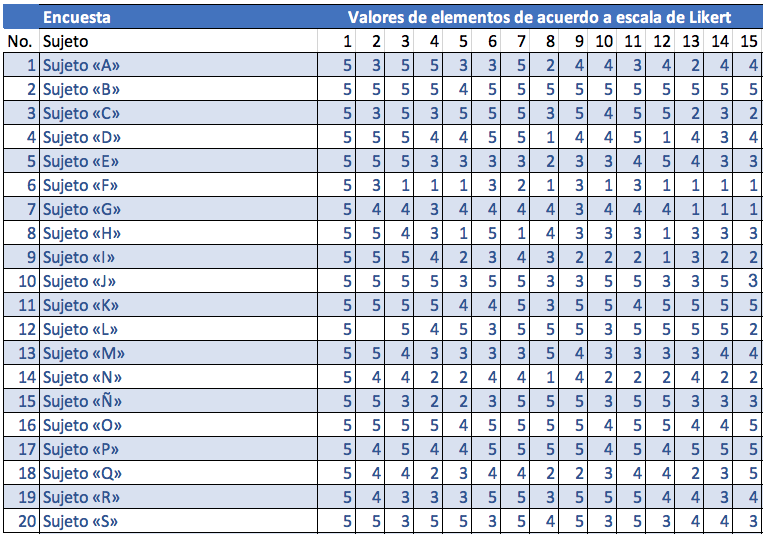

### 5. Cálular los puntajes

Para poder realizar un buen análisis, podemos seguir los siguientes pasos:

1. Desarrolla los cálculos de tu base de datos en Excel y otro programa donde puedas concentrar la información y graficarla.
2. Realiza una sumatoria final con las respuestas de cada uno de los elementos para conocer la información sobre un encuestado en particular.
3. Suma los valores de cada respuesta para saber cuál es el grado de aceptación de cada elemento. 4- Marca los rangos óptimos de respuesta para saber cómo un simple vistazo cuál es el estatus de tus clientes.

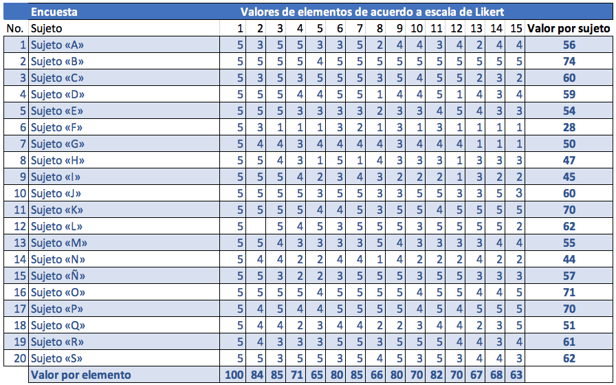

### 6. Calcular la frecuencia de cada elemento

Insertar una tabla de contingencia con cada uno de los elementos:

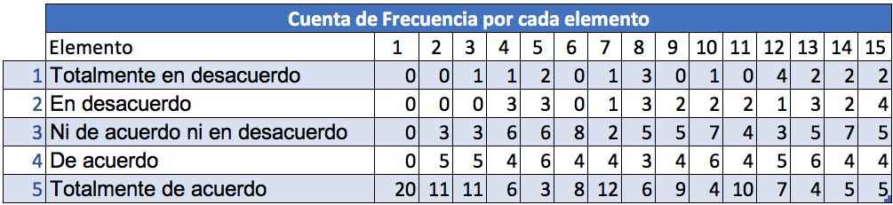

### 7. Elaborar Gráficas

Emplea gráficas y porcentajes para un análisis óptimo de la escala de Likert, ya que así te darás cuenta del tipo de respuesta que recibiste. Te servirá como una herramienta para decisiones estratégicas.

Recuerda: como seres humanos nos relacionamos con la información a través del sentido de la vista. Crea gráficas que te permitan entender mejor el funcionamiento de los enunciados que diseñaste.

Primero, suma los valores individuales de respuesta de acuerdo con cada elemento. Esto te dará un valor absoluto en tu escala de Likert.

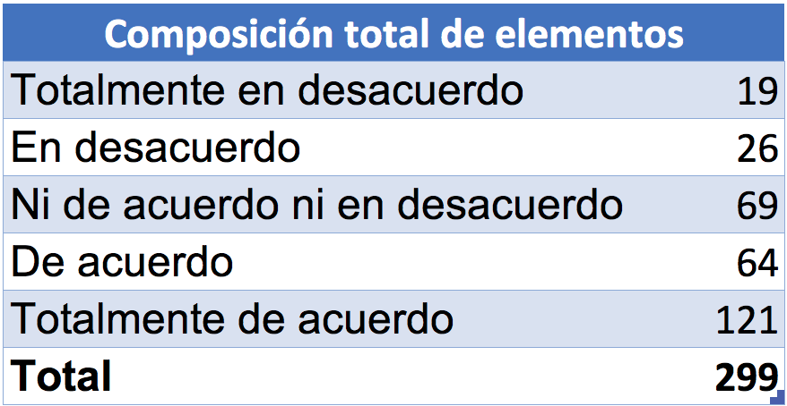

Exprese en porcentaje los valores anteriores para poder generar una gráfica circular, aunque se puede utilizar cualquiera que nos parezca más fácil.

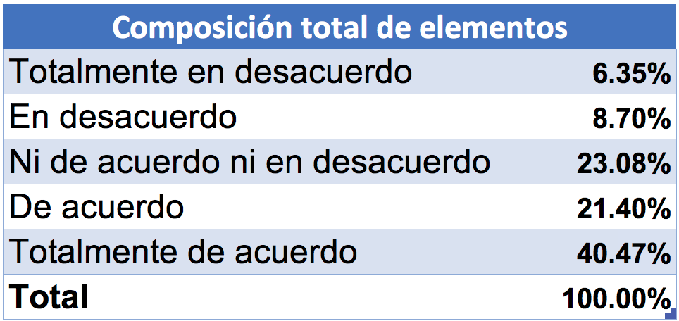

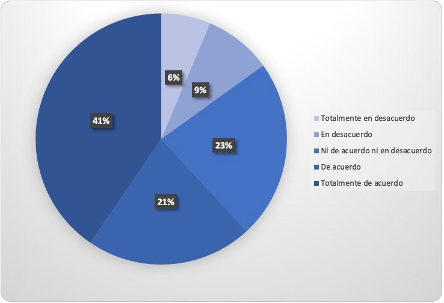

### Análisis de resultados

Una vez que tengamos los resultados, encuentre la moda, que corresponde al dato con frecuencia mayor, y la media. Así tendremos un análisis global rápidamente.

Desglosa los datos de acuerdo con tus necesidades: puedes dividirlos por grupos de edad o por tipo de cliente. Puedes crear una gráfica para cada categoría o, como viste anteriormente, sumar las puntuaciones de cada participante. Así encontrarás un valor total para ese encuestado. Si tu encuesta tuviera un puntaje máximo de 100 de satisfacción por participante:

- Los resultados del 0 al 25 implicarían insatisfacción general.
- Del 26 al 50, insatisfacción con respecto de ciertas características.
- Del 51 al 80, una disposición neutral.
- Del 81 al 100, satisfacción.

Sigue este mismo procedimiento para evaluar la satisfacción con respecto de cada ítem o aspecto evaluado.

## Datos Perdidos

Son aquellos que no están presentes debido a cualquier acontecimiento, como por ejemplo errores en la transcripción de los datos o la ausencia de disposición a responder a ciertas preguntas o elementos de una encuesta. Los datos pueden faltar de manera aleatoria o no aleatoria.

Los datos perdidos o faltantes de forma aleatoria pueden perturbar el análisis de datos dado que disminuyen el tamaño de las muestras y en consecuencia la confiabilidad de los datos. Los datos perdidos no aleatorios ocasionan, además, disminución de la representatividad de la muestra.

### Tratamiento

#### Eliminación

Este procedimiento consiste en eliminar del análisis los casos que presentan observaciones incompletas en algunas delas variables. Este método solo debe utilizarse cuando el proceso de recogida de datos es aleatorio, porque en otro caso introduce sesgo. Otro inconveniente es que el tamaño muestral puede llegar a sufrir una gran reducción y afectar a la representatividad de la muestra.

#### Selección por variables

Se mantienen en la base de datos los casos que tengan datos en las variables que van a ser utilizadas para el análisis. Este procedimiento tiene el inconveniente de generar muestras heterogéneas.

#### Métodos de reemplazo

Los métodos de reemplazo consisten en estimar los valores ausentes en base a los valores válidos de otras variables y/o casos de la muestra. La estimación se puede hacer a partir de la información del conjunto completo de variables o bien de algunas variables especialmente seleccionadas. Usualmente los métodos de reemplazo se utilizan con variables cuantitativas (discretas o continuas), y deben aplicarse con gran precaución porque pueden introducir relaciones inexistentes en los datos realas.

**Principales procedimientos:**

- **Sustitución por la Media**. Consiste en sustituir el valor ausente por la Media de los valores válidos. Este procedimiento plantea inconvenientes como:
  - Dificulta la estimación de las medidas de dispersión
  - Distorsiona la verdadera distribución de la variable,
  - Distorsiona la correlación entre variables dado que añade valores constantes.
- **Sustitución por constante**. Consiste en sustituir los valores ausentes por constantes cuyo valor viene determinado por razones teóricas o relacionadas con la investigación previa. Presenta los mismos inconvenientes que la sustitución por la Media, y solo debe ser utilizado si hay razones para suponer que es más adecuado que el método de la media.
- **Selección por regresión**. Este método consiste en estimar los valores ausentes en base a su relación con otros variables mediante Análisis de Regresión.

  Inconvenientes:
  - Incrementa artificialmente las relaciones entre variables.
  - Hace que se subestime la Variáncia de las distribuciones.
  - Asume que las variables con datos ausentes tienen relación de alta magnitud con las otras variables.